# Fraud Detection - Group 3

## Dimensionality Reduction using PCA

```r
pca_df.pca <- prcomp(df_new[, c(1:7)], centre = TRUE, scale. = TRUE)
summary(pca_df.pca)
```

```
## Importance of components:
##                           PC1    PC2    PC3    PC4     PC5     PC6     PC7
## Standard deviation     1.5447 1.4052 1.0163 0.9572 0.79895 0.22572 0.03015
## Proportion of Variance 0.3409 0.2821 0.1475 0.1309 0.09119 0.00728 0.00013
## Cumulative Proportion  0.3409 0.6230 0.7705 0.9014 0.99259 0.99987 1.00000
```

We have obtained 7 principal components, where each explains a percentate of the total variation of the dataset. PC1 explains 34% of the total variance, PC2 explains 28.21% of the variance etc.

```r
# Calling str() to have a look at your PCA object
str(pca_df.pca)
```

```
## List of 5
##  $ sdev    : num [1:7] 1.545 1.405 1.016 0.957 0.799 ...
##  $ rotation: num [1:7, 1:7] 0.0432 -0.3467 0.1455 0.5144 0.5161 ...
##   ..- attr(*, "dimnames")=List of 2
##   .. ..$ : chr [1:7] "step" "type" "amount" "oldbalanceorg" ...
##   .. ..$ : chr [1:7] "PC1" "PC2" "PC3" "PC4" ...
##  $ center  : Named num [1:7] 8.52 2.85 1.74e+05 9.07e+05 9.24e+05 ...
##   ..- attr(*, "names")= chr [1:7] "step" "type" "amount" "oldbalanceorg" ...
##  $ scale   : Named num [1:7] 1.82 1.35 3.45e+05 2.83e+06 2.87e+06 ...
##   ..- attr(*, "names")= chr [1:7] "step" "type" "amount" "oldbalanceorg" ...
##  $ x       : num [1:101613, 1:7] -1.13 -1.19 -1.45 -0.68 -1.18 ...
##   ..- attr(*, "dimnames")=List of 2
##   .. ..$ : chr [1:101613] "1" "2" "3" "4" ...
##   .. ..$ : chr [1:7] "PC1" "PC2" "PC3" "PC4" ...
##  - attr(*, "class")= chr "prcomp"
```

Here we have a look at the pca object: 1. The center point ($center), scaling ($scale), standard deviation(sdev) of each principal component. 2. The relationship (correlation or anticorrelation, etc) between the initial variables and the principal components ($rotation). 3. The values of each sample in terms of the principal components.

```r
# Plotting pca to get insights

#install.packages("devtools")
library(devtools)
```

[output not shown]

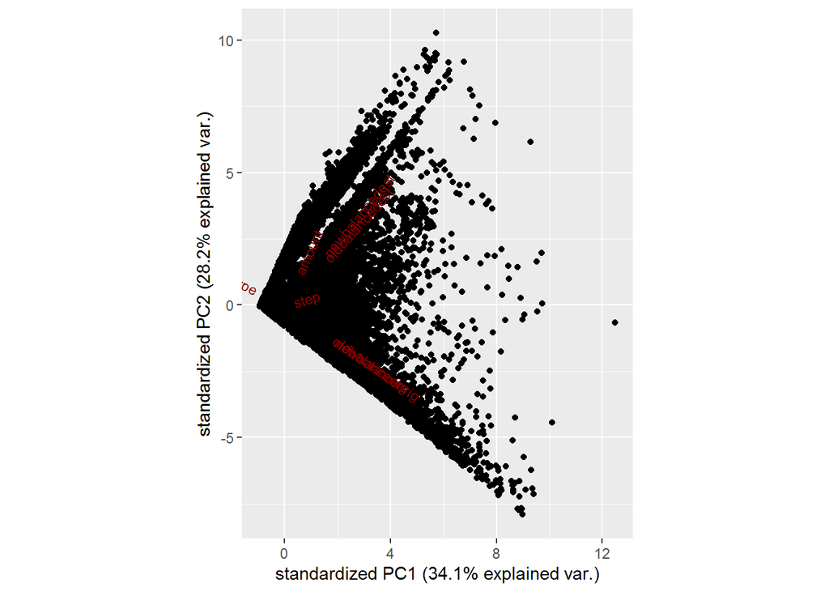

```r
#install_github("vqv/ggbiplot")

# Then Loading ggbiplot library
library(ggbiplot)
ggbiplot(pca_df.pca)
```

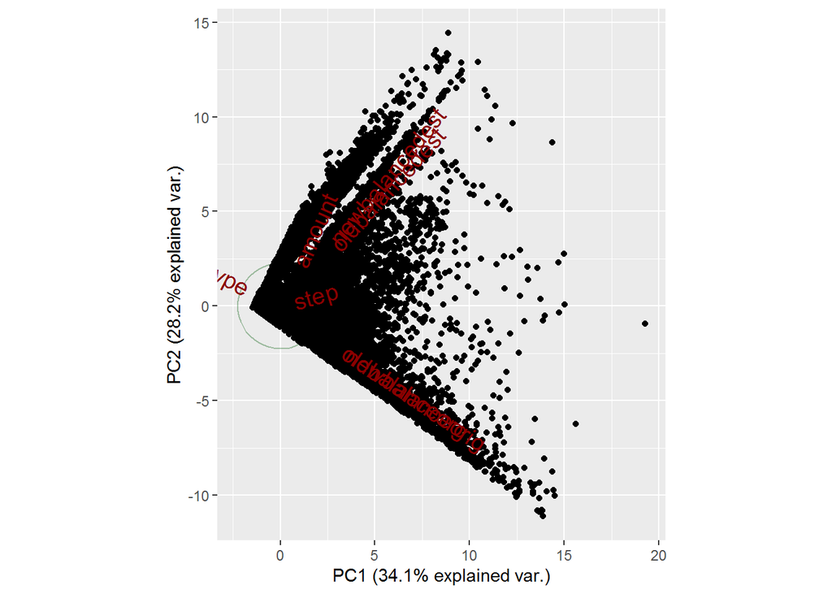

```r
bplot = ggbiplot(pcobj = pca_df.pca,
         choices = c(1,2),
         obs.scale = 1, var.scale = 1,
         varname.size = 5,
         varname.abbrev = FALSE,
         var.axes = TRUE,
         circle = TRUE)
print(bplot)
```

```r
#install.packages("factoextra")
library(factoextra)
```

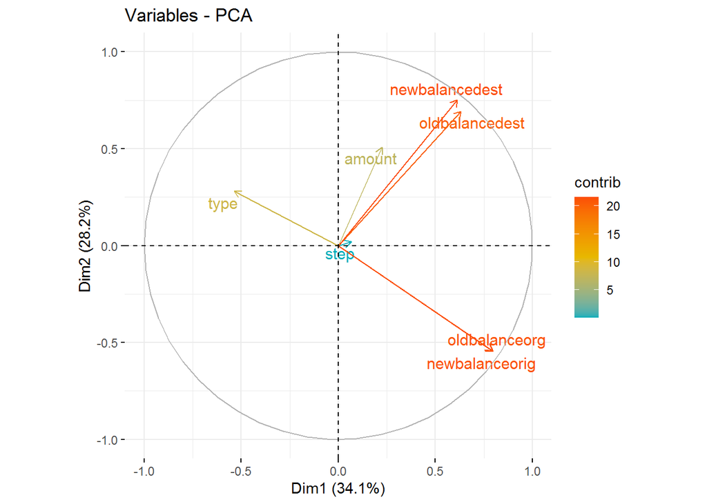

```r
fviz_pca_var(pca_df.pca,
             col.var = "contrib", # Color contribution to PC
             gradient.cols = c("#00AFBB", "#E7B800", "#FC4E07"),
             repel = TRUE # Avoid text overlapping
            )
```

Our graphs show that PC1 contributes 34.1%. New Balance destination,old balance destination, old balance origin and new balance origin contribute highly to PC1.

The type column contribute to PC2.

# Feature Selection using Filter Method

```r
library(caret)
```

```r
# preapring our data
feat_df <- df_new[-8]
```

```r
# Calculating the correlation matrix
CorrelationMatrix <- cor(feat_df)
```

```r
# Find the attributes that are highly correlated
highlycorrelated <- findCorrelation(CorrelationMatrix, cutoff=0.75)
```

```r
# Highly Correlated Attributes

names(feat_df[,highlycorrelated])
```

```
## [1] "newbalanceorig" "newbalancedest"
```

```r
# Dropping the highly correlated attributes
feat_df2 <- feat_df[-highlycorrelated]
```

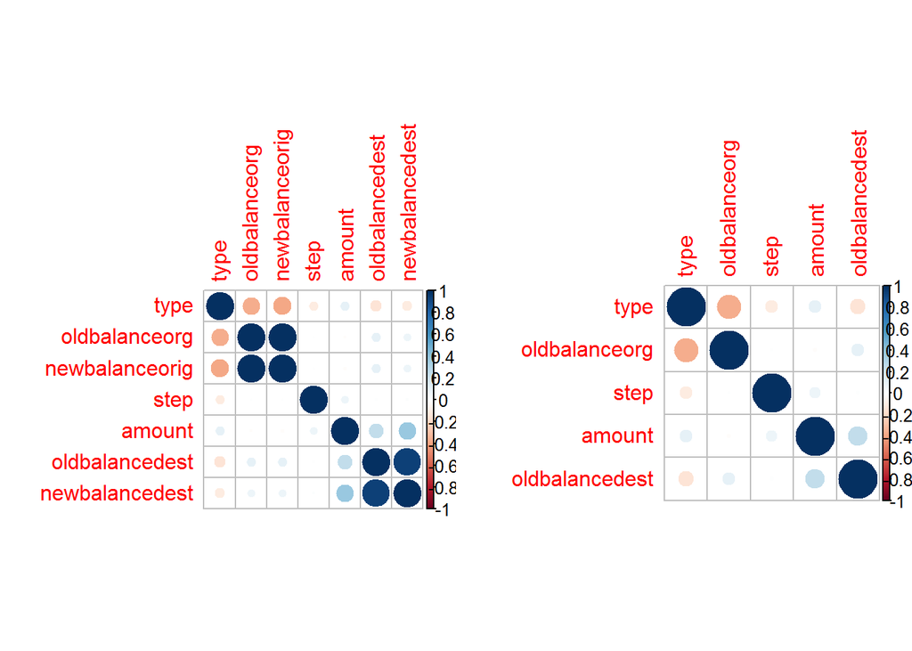

```r
# Performing Graphical Comparison
library(corrplot)
par(mfrow = c(1, 2))
corrplot(CorrelationMatrix, order = "hclust")
corrplot(cor(feat_df2), order = "hclust")
```

```r
# The important features for analysis are:
names(feat_df2)
```

```
## [1] "step"           "type"           "amount"         "oldbalanceorg"
## [5] "oldbalancedest"
```

These are the important features that we will use in our model.